# Homework 2

Dylan Maddux

2024-09-18

```r
library(Stat2Data)
```

## Exercise 2.28

##### A. Total enrollments in mathematics courses at a small liberal arts college were obtained for each semester from Fall 2001 to Spring 2012. Remove the data from 2003 and fit a regression model for predicting spring enrollment (Spring) from fall enrollment (Fall). Prepare the appropriate residual plots and comment on the slight problems with the conditions for inference. In particular, make sure that you plot the residuals against order (or AYear) and comment on the trend.

```r
library(dplyr)
```

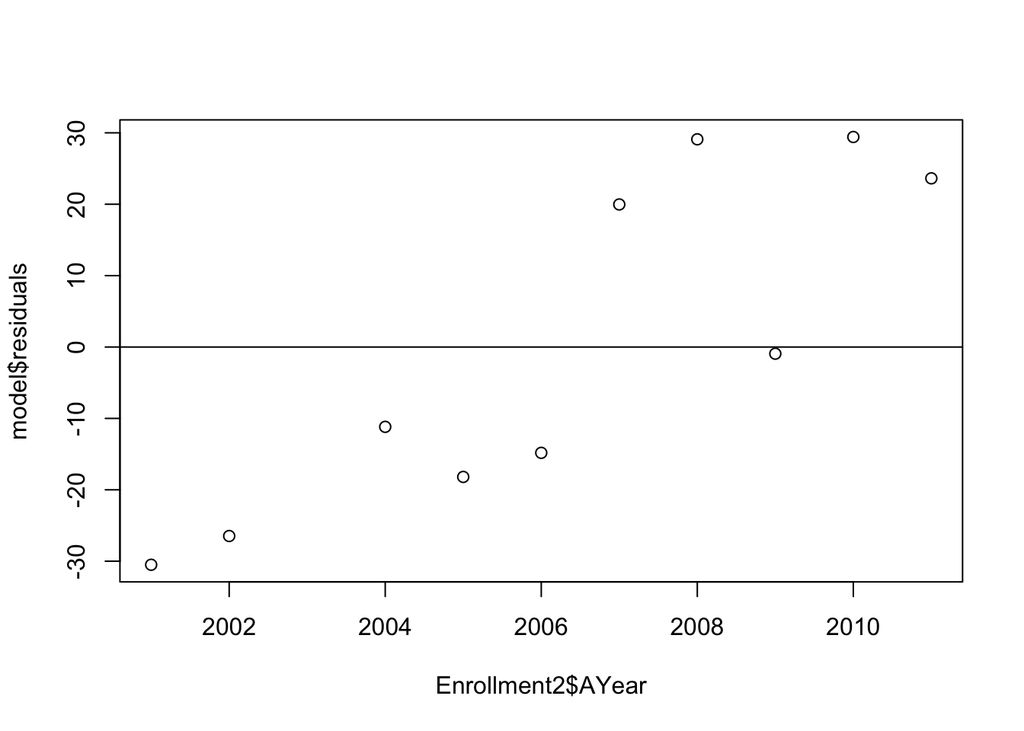

```r
data("MathEnrollment")
Enrollment2 <- MathEnrollment %>%
  filter(AYear != "2003")

model <- lm(Spring~Fall, Enrollment2)
plot(Enrollment2$AYear, model$residuals)
abline(0,0)
```

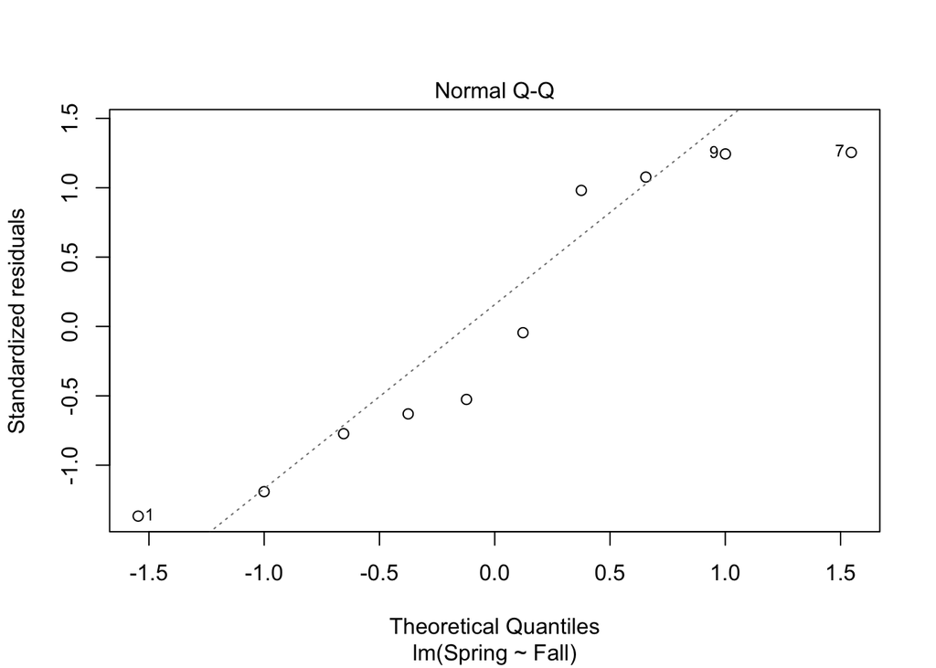

```r
plot(model, 2)
```

The small sample size of n=10 makes meeting the conditions for inference difficult since normality likely cannot be determined from so few data points. The residuals vs order plot displays heteroscedasticity with an increase in the residual trend over time, while the Q-Q plot does not adhere to a normal quantile plot.

##### B. Even though we will be able to improve on this simple linear model in the next chapter, let’s take a more careful look at the model. What percent of the variability in spring enrollment is explained by using a simple linear model with fall enrollment as the predictor?

```r
summary(model)
```

```
##
## Call:
## lm(formula = Spring ~ Fall, data = Enrollment2)
##
## Residuals:
##     Min      1Q  Median      3Q     Max
## -30.500 -17.353  -6.058  22.711  29.418
##
## Coefficients:
##             Estimate Std. Error t value Pr(>|t|)
## (Intercept) 548.0094   106.7236   5.135 0.000891 ***
## Fall         -1.0483     0.3805  -2.755 0.024870 *
## ---
## Signif. codes:  0 '***' 0.001 '**' 0.01 '*' 0.05 '.' 0.1 ' ' 1
##
## Residual standard error: 24.94 on 8 degrees of freedom
## Multiple R-squared:  0.4868, Adjusted R-squared:  0.4227
## F-statistic: 7.589 on 1 and 8 DF,  p-value: 0.02487
```

48.68% of the variability in spring enrollment can be explained through the simple linear model with fall enrollment as the predictor.

##### C. Provide the ANOVA table for partitioning the total variability in spring enrollment based on this model.

```r
anova(model)
```

```
## Analysis of Variance Table
##
## Response: Spring
##           Df Sum Sq Mean Sq F value  Pr(>F)
## Fall       1 4721.1  4721.1  7.5895 0.02487 *
## Residuals  8 4976.5   622.1
## ---
## Signif. codes:  0 '***' 0.001 '**' 0.01 '*' 0.05 '.' 0.1 ' ' 1
```

##### D. Test for evidence of a significant linear association between spring and fall enrollments.

```r
summary(model)
```

```
##
## Call:
## lm(formula = Spring ~ Fall, data = Enrollment2)
##
## Residuals:
##     Min      1Q  Median      3Q     Max
## -30.500 -17.353  -6.058  22.711  29.418
##
## Coefficients:
##             Estimate Std. Error t value Pr(>|t|)
## (Intercept) 548.0094   106.7236   5.135 0.000891 ***
## Fall         -1.0483     0.3805  -2.755 0.024870 *
## ---
## Signif. codes:  0 '***' 0.001 '**' 0.01 '*' 0.05 '.' 0.1 ' ' 1
##
## Residual standard error: 24.94 on 8 degrees of freedom
## Multiple R-squared:  0.4868, Adjusted R-squared:  0.4227
## F-statistic: 7.589 on 1 and 8 DF,  p-value: 0.02487
```

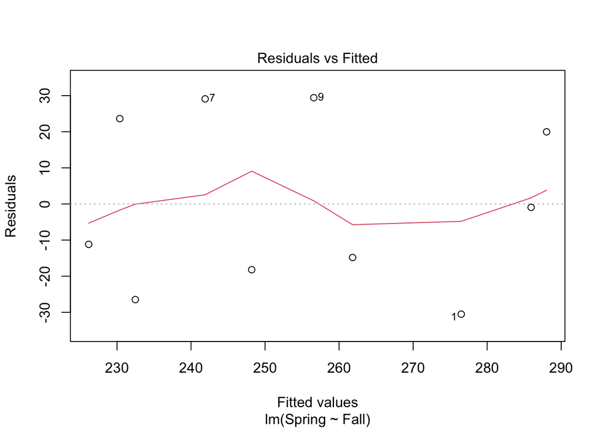

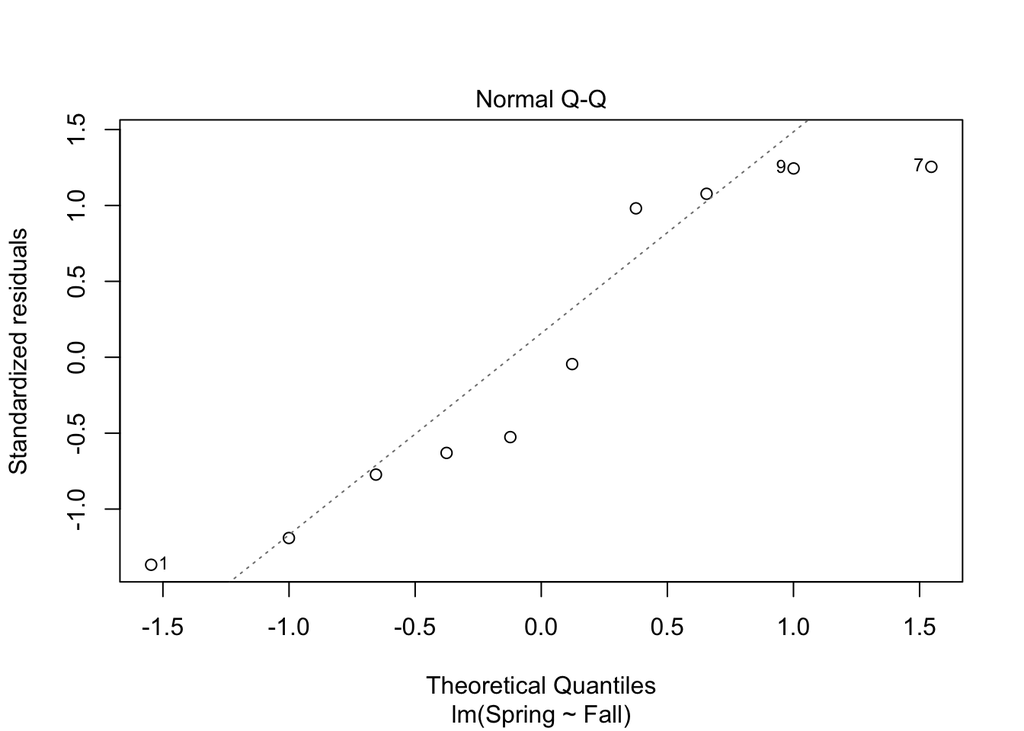

```r
plot(model, 1:2)
```

The p-value under 0.05 of the linear model potentially suggests a significant linear association between spring and fall enrollments. However, the accompanying residual plots do not meet the conditions for inference of normality.

##### E. Provide a 95% confidence interval for the slope of this model. Does your interval contain zero? Why is that relevant?

```r
confint(model)
```

```
##                  2.5 %      97.5 %
## (Intercept) 301.904313 794.1144951
## Fall         -1.925783  -0.1708162
```

The 95% confidence interval for the slope of this model is (-1.926,-0.171), which does not contain zero. This is relevant because it means we are 95% confident that the true population slope is not zero and thus there is a statistically significant linear relationship between the Fall and Spring enrollment numbers in this model.

## Exercise 2.40

##### A. The file GrinnellHouses contains data from 929 house sales in Grinnell, Iowa, between 2005 and into 2015. Find a 90% confidence interval for the mean SalePrice of a home that is listed at $300,000.

```r
data("GrinnellHouses")
model2 <- lm(SalePrice~ListPrice, GrinnellHouses)
summary(model2)
```

```
##
## Call:
## lm(formula = SalePrice ~ ListPrice, data = GrinnellHouses)
##
## Residuals:
##    Min     1Q Median     3Q    Max
## -55942  -3275    846   4141  44168
##
## Coefficients:
##               Estimate Std. Error t value Pr(>|t|)
## (Intercept) -1.448e+02  5.236e+02  -0.277    0.782
## ListPrice    9.431e-01  3.201e-03 294.578   <2e-16 ***
## ---
## Signif. codes:  0 '***' 0.001 '**' 0.01 '*' 0.05 '.' 0.1 ' ' 1
##
## Residual standard error: 8019 on 927 degrees of freedom
## Multiple R-squared:  0.9894, Adjusted R-squared:  0.9894
## F-statistic: 8.678e+04 on 1 and 927 DF,  p-value: < 2.2e-16
```

```r
hyp = data.frame(ListPrice=c(300000))
predict(model2, newdata=hyp, interval="confidence", level = 0.9)
```

```
##        fit    lwr      upr
## 1 282774.6 281833 283716.2
```

The 90% confidence interval for the mean Sale Price of this hypothetical home is between $281,833 and $283,716.

##### B. Find a 90% prediction interval for the SalePrice of a home that is listed at $300,000.

```r
predict(model2, newdata=hyp, interval="prediction", level = 0.9)
```

```
##        fit      lwr      upr
## 1 282774.6 269537.3 296011.9
```

The 90% prediction interval for the Sale Price of this hypothetical home is between $269,537 and $296,012.

##### C. Give interpretative sentences for your answers to (a) and (b) so that the distinction between what they mean is clear.

Given the context of this dataset and our linear model, we can be 90% confident that any single house listed at $300,000 would be sold for between $269,537 and $296,012, while we can be 90% confident that the mean sale price of all houses listed at $300,000 would be between $281,833 and $283,716.

## Exercise 2.44

##### A. Determine a 95% confidence interval for the mean price of a 450-page textbook in the population.

```r
data("TextPrices")
model3 <- lm(Price~Pages, TextPrices)

par = data.frame(Pages=c(450))
predict(model3, newdata=par, interval="confidence", level = 0.95)
```

```
##        fit      lwr      upr
## 1 62.87549 51.73074 74.02024
```

The 95% confidence interval for the mean price of this hypothetical textbook is between $51.73 and $74.02.

##### B. Determine a 95% prediction interval for the price of a particular 450-page textbook in the population.

```r
predict(model3, newdata=par, interval="prediction", level = 0.95)
```

```
##        fit       lwr      upr
## 1 62.87549 0.9035981 124.8474
```

The 95% prediction interval for the mean price of this hypothetical textbook is between $0.90 and $124.85.

##### C. How do the midpoints of these two intervals compare? Explain why this makes sense.

The midpoints of these two intervals are the same because it represents the fitted value from the model for a textbook with 450 pages.

##### D. How do the widths of these two intervals compare? Explain why this makes sense.

The width of the prediction interval is much bigger because it predicts one particular data point, whereas the confidence interval predicts the mean price of textbooks at that value.

##### E. What value for number of pages would produce the narrowest possible prediction interval for its price? Explain.

```r
mean(TextPrices$Pages)
```

```
## [1] 464.5333
```

The mean price of textbooks from this dataset, 465 pages, would produce the narrowest possible prediction interval for its price since the most data points would be near the mean, meaning that the predictive model would be most accurate.

##### F. Determine a 95% prediction interval for the price of a particular 1500-page textbook in the population. Do you really have 95% confidence in this interval? Explain.

```r
par = data.frame(Pages=c(1500))
predict(model3, newdata=par, interval="prediction", level = 0.95)
```

```
##        fit      lwr     upr
## 1 217.5704 143.3587 291.782
```

The 95% prediction interval for the price of a particular 1500-page textbook would be between $143.36 and $291.78. I am not 95% confident in this interval since the number of pages exceeds any of the textbooks in the dataset.

## Exercise 2.52

```r
model2 <- lm(SalePrice~ListPrice, GrinnellHouses)
```

##### A. Refer to the GrinnellHouses datset. Refit the simple linear regression model for predicting SalePrice from ListPrice and answer these questions.Give a 95% confidence interval for the slope, and write a sentence that interprets this interval in context.

```r
confint(model2)
```

```
##                    2.5 %      97.5 %
## (Intercept) -1172.379507 882.7136251
## ListPrice       0.936782   0.9493477
```

The 95% confidence interval for the slope is (0.937, 0.949), meaning that we are 95% confident that the Sale Price increases by between $936.78 and $949.35 for every $1000 increase in ListPrice.

##### B. Test the hypothesis that the true intercept for the regression line is 0.

```r
summary(model2)
```

```
##
## Call:
## lm(formula = SalePrice ~ ListPrice, data = GrinnellHouses)
##
## Residuals:
##    Min     1Q Median     3Q    Max
## -55942  -3275    846   4141  44168
##
## Coefficients:
##               Estimate Std. Error t value Pr(>|t|)
## (Intercept) -1.448e+02  5.236e+02  -0.277    0.782
## ListPrice    9.431e-01  3.201e-03 294.578   <2e-16 ***
## ---
## Signif. codes:  0 '***' 0.001 '**' 0.01 '*' 0.05 '.' 0.1 ' ' 1
##
## Residual standard error: 8019 on 927 degrees of freedom
## Multiple R-squared:  0.9894, Adjusted R-squared:  0.9894
## F-statistic: 8.678e+04 on 1 and 927 DF,  p-value: < 2.2e-16
```

We cannot reject the null hypothesis that the true intercept for the regression line is 0 since the p-value is 0.782.

##### C. Given the result in part (b), we might consider a simple model that SalePrice is predicted as a simple fraction of the ListPrice, where the estimate of that fraction is the line’s slope. If this model works, we could also look for this fraction by computing a 95% confidence interval for the collection of ratios of SalePrice / ListPrice. Find this interval and compare to your answer in (a).

```r
ghouses <- GrinnellHouses %>%
  mutate(Ratio = SalePrice/ListPrice)
ratio <- t.test(ghouses$Ratio)
print(ratio$conf.int)
```

```
## [1] 0.9311611 0.9401158
## attr(,"conf.level")
## [1] 0.95
```

The 95% confidence interval for the collection of ratios of Sale Price to List Price is (0.931, 0.940). The values in this interval are marginally lower than the previous model but still extremely similar, indicating a strong congruence between the two models.